# Intro to Supervised Learning (Prediction)

```r
#install.packages("randomForest")
#install.packages("e1071")
#install.packages("nnet")
#install.packages("caret")
#install.packages("gbm")
#install.packages("mlbench")
#install.packages("glmnet")
#install.packages("kernlab")
#install.packages("plotROC")
library(plotROC) # required to use geom_roc
library(kernlab)
library(caret)
library(mlbench) # contains a number of benchmark machine learning data sets
library(tidyr)
library(gbm)
library(glmnet)
library(randomForest)
library(nnet)
```

### 1. Introduction

In most modeling applications it isn’t clear which model (or even which class of model) will perform best. The `caret` package (**C**lassification **A**nd **RE**gression **T**raining) provides a set of functions designed to streamline the process of creating and comparing many predictive models.

## 2. Training and Test Set Splitting

A common practice in predictive modeling is to withhold a fraction of the data (15-20% is typical) as a **test set**, which is *only used* for evaluation purposes after a final model has been determined. The rest of the data, known as the **training set**, is used to explore the data and build/assess candidate models.

It is easy to randomly subset the data into training and test sets ourselves using the `sample` function:

```r
data(BostonHousing) # Data from mlbench, type ?BostonHousing for variable descriptions

set.seed(22) ## It is good practice to set a set to ensure reproducibility of your results
test.id <- sample(1:nrow(BostonHousing), size = .2*nrow(BostonHousing))

train.data <- BostonHousing[-test.id,]
test.data <- BostonHousing[test.id,]

table(test.data$chas)
```

```
##
##  0  1
## 98  3
```

Randomly assigning the training and test sets works well for most applications. However, notice in this example that the test set has only has 3 cases with `chas = 1`. If this variable were important to our analysis (for example, the outcome variable) we might want to enforce balance across the training/test sets.

If the outcome variable, or key covariates, are highly imbalanced, the function `createDataPartition` can be used to create training/testing sets using stratified random sampling:

```r
set.seed(22)
# stratifies to ensure some cases with each category of "chas" make it into both sets
test.id <- createDataPartition(BostonHousing$chas, p = .2, list = FALSE)

train.data <- BostonHousing[-test.id,]
test.data <- BostonHousing[test.id,]

prop.table(table(train.data$chas))
```

```
##
##          0          1
## 0.93069307 0.06930693
```

```r
prop.table(table(test.data$chas)) # Balance in each set
```

```
##
##          0          1
## 0.93137255 0.06862745
```

## 3. Model Building

Once the training and test sets have been created, we can start the process of model building. `train` is one of `caret`’s workhorse functions and is used to train, tune, and assess a model. But before using `train`, we need to specify a set of options using the `trainControl` function:

```r
# Evaluate models using 5-fold cross validation, repeated 10 times
fit.control <- trainControl(method = "repeatedcv", number = 5, repeats = 10)
```

While `trainControl` provides a number of different methods for model assessment (estimating the expected prediction error), we will focus on repeated cross validation.

Now that we’ve set up how our model will be assessed, it is time to actually fit a model. `caret` uses a common formula syntax and allows you to choose from over [200 machine learning models accommodated by the package](http://topepo.github.io/caret/available-models.html). The left-hand side of the ~ contains the response variable, while the right-hand side contains the predictor variables (typically separated by +’s)

The example below fits a [gradient boosting machine](http://www.saedsayad.com/docs/gbm2.pdf) to the `BostonHousing` data, using the variable “tax” as the outcome, and all other columns of the dataframe as predictors (the . character is shorthand for all other variables).

```r
set.seed(7)
gbm.fit <- train(tax ~ ., data = train.data, method = "gbm", trControl = fit.control, verbose = FALSE)

gbm.fit
```

```
## Stochastic Gradient Boosting
##
## 404 samples
##  13 predictor
##
## No pre-processing
## Resampling: Cross-Validated (5 fold, repeated 10 times)
## Summary of sample sizes: 322, 323, 324, 323, 324, 324, ...
## Resampling results across tuning parameters:
##
##   interaction.depth  n.trees  RMSE      Rsquared   MAE
##   1                   50      56.16025  0.8901067  35.35096
##   1                  100      54.35762  0.8959389  34.17497
##   1                  150      53.54299  0.8989354  33.97584
##   2                   50      50.20389  0.9121993  31.48902
##   2                  100      46.81509  0.9229608  29.48545
##   2                  150      44.70523  0.9297727  28.34785
##   3                   50      46.57285  0.9242350  29.10205
##   3                  100      42.61606  0.9361207  26.88305
##   3                  150      40.63623  0.9419110  25.89223
##
## Tuning parameter 'shrinkage' was held constant at a value of 0.1
##
## Tuning parameter 'n.minobsinnode' was held constant at a value of 10
## RMSE was used to select the optimal model using the smallest value.
## The final values used for the model were n.trees = 150,
##  interaction.depth = 3, shrinkage = 0.1 and n.minobsinnode = 10.
```

1. `n.tree`: the number of trees to be fit, this is the number of boosting iterations the algorithm runs for
2. `interaction.depth`: how complex each tree is allowed to get
3. `shrinkage`: a parameter applied to each tree that governs the learning rate, it controls how quickly the algorithms adapts the model
4. `n.minobsinnode`: the minimum number of training samples in a node to commence splitting

Right now you need not understand all (or any!) these parameters. More important is the general knowledge that these parameters govern the nature of the GBM model being fit; different combinations of tuning parameters can yield very different models.

`caret` has methods for automatically generating different values of the tuning parameters to try. If you are unfamiliar with the type of model being fit, I suggest starting with the default **tuning grid**; but, `caret` does allow you to provide custom tuning grids, which can be used to assess broader ranges of tuning parameter combinations:

```r
gbm.grid <- expand.grid(interaction.depth = c(1, 3, 5),
                        n.trees = (1:10)*100,
                        shrinkage = 0.1,
                        n.minobsinnode = 20)

set.seed(7)
gbm.fit2 <- train(tax ~ ., data = train.data, method = "gbm", trControl = fit.control, verbose = FALSE, tuneGrid = gbm.grid)

gbm.fit2
```

[output not shown]

You’ll notice that this tuning grid noticeably increased the time it took `train` to run. Each row in the tuning grid corresponds with a model that `train` needs to fit. So while larger tuning grids have to the potential to be more informative, they’re also computationally expensive.

Instead of exhaustively searching large tuning grids, a better strategy is to narrow in on tuning parameter combinations that you believe might be promising. Start with a small, coarse grid (ie: 10, 20, 30, 40) and see which values are best. Use this knowledge to refine your search, for example if it looks like the minimum RMSE is between 20 and 30 you can refine your search to (20, 22, 24, 26, 28, 30).

For any particular class of model, finding the optimal configuration of tuning parameters can have a huge impact on predictive ability. If you’ve settled on a model class you should spend a fair bit of time exploring tuning parameter configurations.

**Question #1**

Load the `glmnet` package and fit an [Elastic Net](https://en.wikipedia.org/wiki/Elastic_net_regularization) regression model to the `BostonHousing` data using `method = "glmnet"`. Be sure you use `set.seed(7)`. Also, be sure to remove the verbose argument as this argument does not exist for glmnet. Store your trained object as “glmnet.fit”

**Question #2**

Using the default tuning parameter grid, which tuning parameter combination (for your Elastic Net model) appears to provide the best prediction? How does this model compare with the best GBM model?

## 3. Plotting Model Profiles

`caret` can be used with `ggplot` to visually display relationship between estimated performance measures and model tuning parameters. The plot below visualizes the RMSE of the various GBM models that we fit:

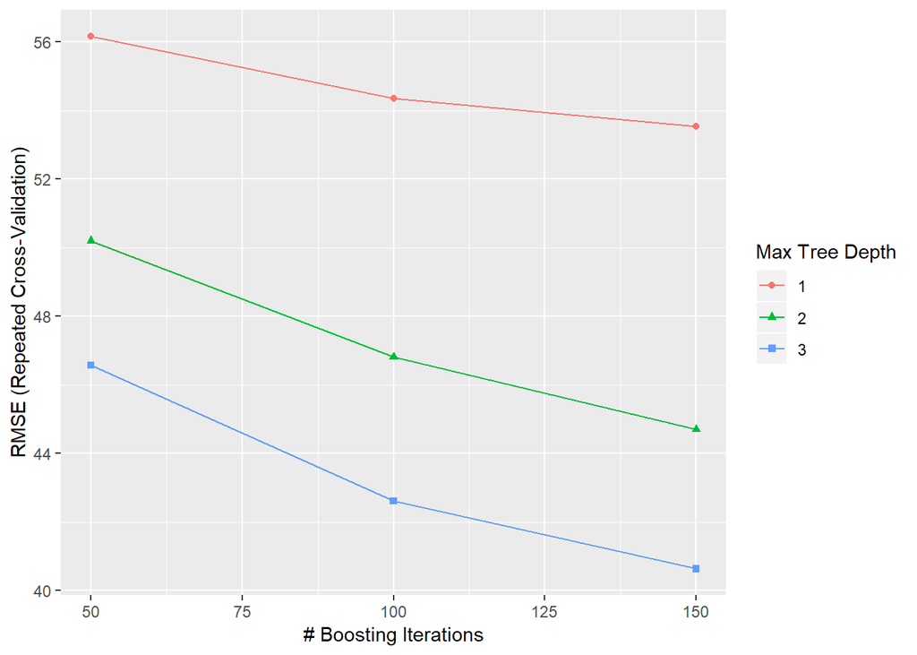

```r
library(ggplot2)
ggplot(gbm.fit)
```

We clearly see that RMSE continues to decline with more boosting iterations. This suggests we might be able to find even better models if we explored tuning the number of boosting iterations (n.trees) to values beyond 150.

As an alternative to RMSE, we could assess performance using $R^2$:

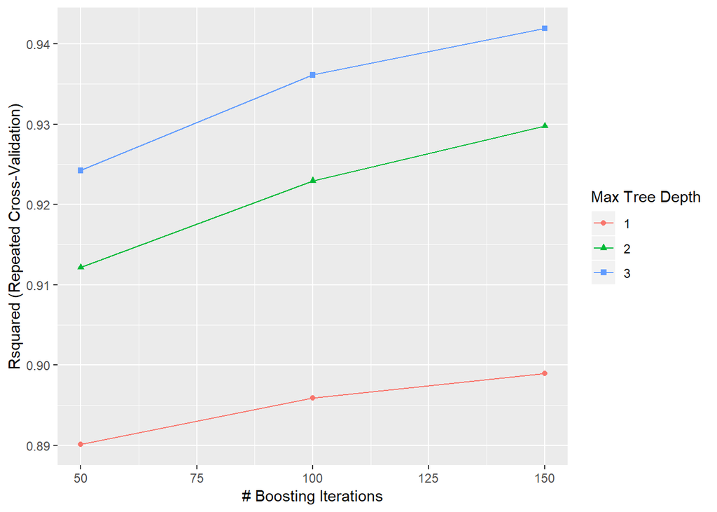

```r
ggplot(gbm.fit, metric = "Rsquared")
```

Other plot types are available:

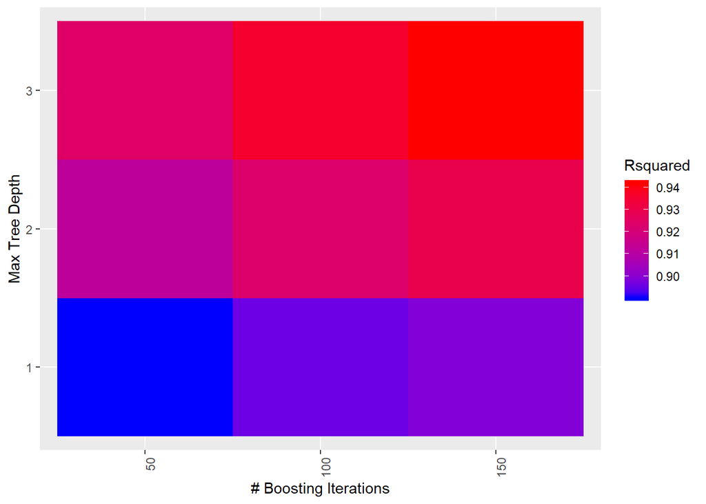

```r
ggplot(gbm.fit, metric = "Rsquared", plotType = "level") +
  theme(axis.text.x = element_text(angle = 90, hjust = 1)) +
  scale_fill_continuous(low = "blue", high = "red")
```

## 4. Comparing Many Models

So far we’ve fit a number of GBM models and found the best model of this group. Oftentimes we don’t want to limit ourselves to choosing the best GBM model, we want to compare models of various different types.

Let’s start by fitting a familar linear regression model to the `BostonHousing` data:

```r
set.seed(7)
lm.fit <- train(tax ~ ., data = train.data, method = "lm", trControl = fit.control)

lm.fit
```

```
## Linear Regression
##
## 404 samples
##  13 predictor
##
## No pre-processing
## Resampling: Cross-Validated (5 fold, repeated 10 times)
## Summary of sample sizes: 322, 323, 324, 323, 324, 324, ...
## Resampling results:
##
##   RMSE      Rsquared   MAE
##   58.01384  0.8804641  36.25765
##
## Tuning parameter 'intercept' was held constant at a value of TRUE
```

There are no tuning parameters for linear regression, so this model is best in its class by default. Also, notice how we set the *same seed* immediately prior to training this model. This is essential to ensure a fair comparison of multiple models using the `resamples` function:

```r
resamps <- resamples(list(GBM = gbm.fit,
                          LM = lm.fit))
summary(resamps)
```

```
##
## Call:
## summary.resamples(object = resamps)
##
## Models: GBM, LM
## Number of resamples: 50
##
## MAE
##         Min.  1st Qu.   Median     Mean  3rd Qu.     Max. NA's
## GBM 20.61587 24.04779 25.21680 25.89223 28.19266 33.23290    0
## LM  28.17433 33.93921 35.56577 36.25765 38.62709 45.50674    0
##
## RMSE
##         Min.  1st Qu.   Median     Mean  3rd Qu.     Max. NA's
## GBM 30.53623 37.18740 40.15097 40.63623 44.44082 53.76050    0
## LM  46.39754 53.94218 58.42734 58.01384 62.59135 70.08861    0
##
## Rsquared
##          Min.   1st Qu.    Median      Mean   3rd Qu.      Max. NA's
## GBM 0.8950020 0.9324152 0.9425673 0.9419110 0.9509626 0.9708067    0
## LM  0.7968197 0.8587528 0.8808774 0.8804641 0.9020624 0.9319510    0
```

Notice how the mean RSME for `GBM` is exactly what is reported in the last row of the printed output of `gbm.fit`, this is because `resamples` knows to use the best model in fit object it is given.

`resamples` is minimally compatible with `ggplot`:

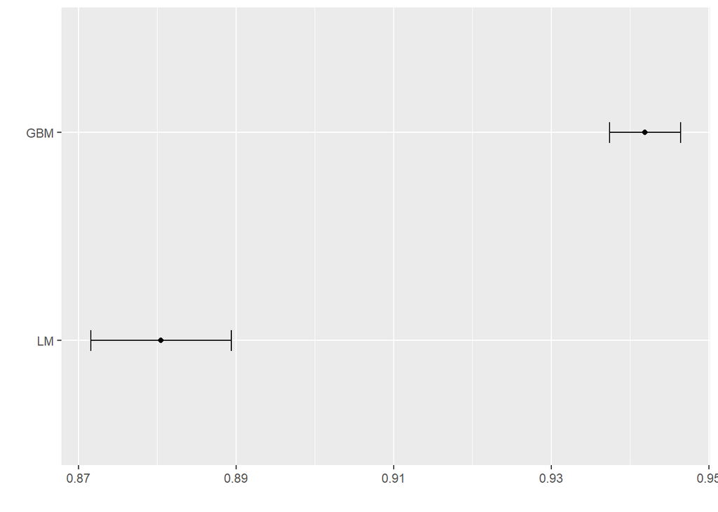

```r
ggplot(resamps, metric = "Rsquared")
```

For more elagant graphics, we need to do some extra work:

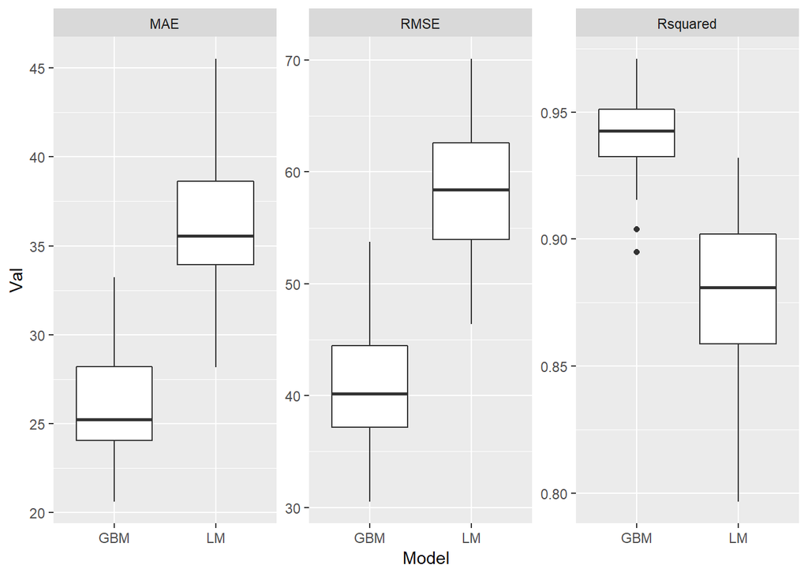

```r
#head(resamps$values)
resamps2 <- gather(resamps$values, key = "Var", value = "Val", 2:ncol(resamps$values))
resamps2 <- separate(resamps2, col = "Var", into = c("Model", "Metric"), sep = "~")

ggplot(resamps2, aes(x = Model, y = Val)) + geom_boxplot() + facet_wrap(~ Metric, scales = "free")
```

**Question 3**

Write code that creates a figure similar to the one above, but includes your gradient boosted machine, linear regression, and elastic net regression models (ie: your graph should three models instead of just two).

## 5. Using Test Set

Once we’ve decided upon a single model, the last step is to see how well it performs on the test set. This provides a final out-of-sample test of the model’s efficacy. We generate predicted values from a model using the `predict` function. `predict` automatically knows to the use best model within the train object `gbm.fit`:

```r
preds <- predict(gbm.fit, newdata = test.data)

sqrt(mean((test.data$tax - preds)^2))
```

```
## [1] 29.04744
```

## 6. Classification

So far we’ve learned how to build and evaluate predictive models for numeric outcomes. We’ll now take a look at classification models for categorical outcomes. To do so, we’ll use [Fisher’s famous iris data set](https://en.wikipedia.org/wiki/Iris_flower_data_set), which contains measurements for 50 flowers from 3 different species of iris:

```r
data("iris")
head(iris)
```

```
##   Sepal.Length Sepal.Width Petal.Length Petal.Width Species
## 1          5.1         3.5          1.4         0.2  setosa
## 2          4.9         3.0          1.4         0.2  setosa
## 3          4.7         3.2          1.3         0.2  setosa
## 4          4.6         3.1          1.5         0.2  setosa
## 5          5.0         3.6          1.4         0.2  setosa
## 6          5.4         3.9          1.7         0.4  setosa
```

Like before, we’ll start by creating training and test data partitions:

```r
set.seed(22)
test.id <- sample(1:nrow(iris), size = .2*nrow(iris))

train.data <- iris[-test.id,]
test.data <- iris[test.id,]
```

This time we aren’t concerned about balancing the outcome variable (since there are 50 flowers of each species). But in other applications you might want to consider the `createDataPartition`.

Like before, we’ll next setup how our models will be assessed using the `trainControl` function, which we need to set up before any model fitting can be done:

```r
# Evaluate models using 5-fold cross validation, repeated 10 times
fit.control <- trainControl(method = "repeatedcv", number = 5, repeats = 10)
```

We’re now ready to train some models:

```r
### Random Forest model
set.seed(7)
rf.fit <- train(Species ~ ., data = train.data, method = "rf", trControl = fit.control, verbose = FALSE)

### Neural Net model
set.seed(7)
nn.fit <- train(Species ~ ., data = train.data, method = "nnet", trControl = fit.control, verbose = FALSE, trace = FALSE)
```

Like before, we won’t into the details of random forest or neural net models here. But each are very popular classification models that accommodate highly non-linear relationships between predictor variables.

The function `confusionMatrix` provides the **confusion matrix**, a summary of how the model classified each observation. It is useful in understanding the types of errors the model made:

```r
confusionMatrix(rf.fit)
```

```
## Cross-Validated (5 fold, repeated 10 times) Confusion Matrix
##
## (entries are percentual average cell counts across resamples)
##
##             Reference
## Prediction   setosa versicolor virginica
##   setosa       35.0        0.0       0.0
##   versicolor    0.0       29.4       3.1
##   virginica     0.0        2.3      30.2
##
##  Accuracy (average) : 0.9467
```

```r
confusionMatrix(nn.fit)
```

```
## Cross-Validated (5 fold, repeated 10 times) Confusion Matrix
##
## (entries are percentual average cell counts across resamples)
##
##             Reference
## Prediction   setosa versicolor virginica
##   setosa       35.0        0.0       0.0
##   versicolor    0.0       30.0       0.5
##   virginica     0.0        1.7      32.8
##
##  Accuracy (average) : 0.9783
```

In this example, We see that both models correctly classify the majority of observations (the diagonal), including all of the setosa flowers. We also can see that the random forest model had a tendency to incorrectly classify virginica flowers as versicolor (on average 3.1 misclassifications of this type across our 10 repeats). Contrast this with the neural net model, which averaged only 0.5 of these misclassifications across the 10 repeats.

```r
resamps <- resamples(list(RF = rf.fit, NN = nn.fit))
summary(resamps)
```

```
##
## Call:
## summary.resamples(object = resamps)
##
## Models: RF, NN
## Number of resamples: 50
##
## Accuracy
##         Min.   1st Qu.    Median      Mean 3rd Qu. Max. NA's
## RF 0.8695652 0.9166667 0.9565217 0.9465507       1    1    0
## NN 0.9130435 0.9583333 1.0000000 0.9783159       1    1    0
##
## Kappa
##         Min.   1st Qu.    Median      Mean 3rd Qu. Max. NA's
## RF 0.8056338 0.8745092 0.9348442 0.9197809       1    1    0
## NN 0.8700565 0.9375000 1.0000000 0.9674163       1    1    0
```

The `resamples` function seems to confirm the superiority of the neural net model for this application.

## 7. Other Performance Measures

The previous example used *classification accuracy* (the reciprocal of *misclassification error*) as the performance measure for evaluating each model. `caret` also allows for other summary functions to be used to describe model performance. One built-in function is `twoClassSummary`, which computes sensitivity, specificity, and area under the ROC curve (AUC) for *binary classification problems*, our situations where the outcome is a categorical variable with two categories. We will explore these metrics using the classic example of classifying emails as spam or ham (not spam):

```r
data("spam") # Predict whether an email is spam
## type ?spam for info on the spam dataset

# Exlcude missing data
spam <- spam[complete.cases(spam),]

# Quickly partition the data
set.seed(14)
train.id <- sample(1:nrow(spam), size = .8*nrow(spam))
train.spam <- data.frame(spam[train.id, ])
test.spam <- data.frame(spam[-train.id, ])

## Set up trainControl
fit.control <- trainControl(method = "repeatedcv", number = 5, repeats = 10, classProbs = TRUE, savePredictions = TRUE,  summaryFunction=twoClassSummary) # The classProbs and savePredictions are needed to create ROC curves
```

Notice we’ve added a number of new arguments to `trainControl`, the argument `classProbs` requests the predicted probabilities get calculated for each class for each observation, the argument `savePredictions`saves these predictions. `summaryFunction = twoClassSummary` is a built-in option that tells `caret` to report AUC, sensitivity, and specificity.

Now let’s fit a model and plot the ROC curve:

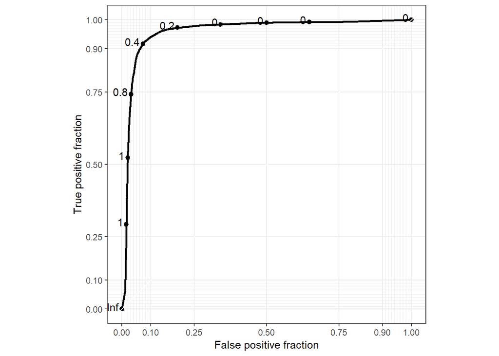

```r
### Simple glm model (logistic regression)
set.seed(7)
glm.fit <- train(type ~ ., data = train.spam, method = "glm", family = "binomial", trControl = fit.control, metric = "ROC")

## ROC Curve (geom_roc from plotROC package)
ggplot(glm.fit$pred, aes(d = obs, m = spam)) +
  geom_roc() +
  coord_equal() +
  style_roc()
```

In the aes argument, “d” is short for disease status, which is the true class of each observation. “m” is short for marker, which is the predicted probability for the disease class. We see from our ROC plot that this simple logistic regression classifer works pretty well. For more details on creating ROC curves using ggplot, visit: https://sachsmc.github.io/plotROC/ **Question 4**

For the spam classification example, construct an ROC curve using the *test data*.

## 8. Summary

At this point we’ve covered many of the basic model building steps in `caret`. Two important topics we haven’t covered are **pre-processing** and how to decide which models to try. We will slowly explore those topics, along with a few other things that commonly come up in data science applications, using detailed case studies throughout the remainder of the semester.

## 9. Additional Questions

**Question 5**

Choose a data set with a *numeric outcome variable* from the [mlbench package](https://www.rdocumentation.org/packages/mlbench/versions/2.1-1) and use `caret` to fit and compare three models of your choosing (see https://rdrr.io/cran/caret/man/models.html for possible options, at this point you don’t need to be familar with the type of model to use it). Your final product should be a ggplot visual comparing the three models.

**Question 6**

Choose a data set with a *categorical outcome variable* from the [mlbench package](https://www.rdocumentation.org/packages/mlbench/versions/2.1-1) and use `caret` to fit and compare three models of your choosing. Your final product should be a ggplot visual comparing the three models.

**Extra Credit**

The following code generates simulated data containing 50 observations and 5 variables; however, only 2 of these variables are actually related to the outcome:

```r
set.seed(123)
n <- 50
p <- 5
X <- matrix(runif(n*p,0,1), nrow = n, ncol = p)
true_beta <- c(1,-1,0,0,0)
y <- X %*% true_beta + rnorm(n, mean = 0,sd = 1.5)
```

Implement 5-fold cross validation manually (Hint: use the `sample` function to partition the data) and estimate the expected prediction error of a linear model (fit using the `lm` function) containing all 5 predictors with the expected prediction error of a linear model containing only the first two predictors. Run your code a few times with different seeds and briefly describe your findings. Does using only the first two predictor variables lead to superior out of sample prediction? If so, why? Instead of using cross validation, suppose you have fit each model to the full data, which would have led to a smaller MSPE on the full data set?